# Assignment 2

Feiyu Zheng (fz114)

2/4/2022

## 1. Download the dataset on restaurant inspection in csv format.

```r
# read data from csv file and convert to tibble
dataset <- as_tibble(read_csv("./NYRestaurantInspection2022.csv",
                              na = c("", "N/A"), show_col_types = F))
# show dataset
dataset
```

```
## # A tibble: 373,818 × 26
##       CAMIS DBA             BORO  BUILDING STREET ZIPCODE PHONE `CUISINE DESCR…`
##       <dbl> <chr>           <chr> <chr>    <chr>    <dbl> <chr> <chr>
##  1 50017056 SILVER SPOON D… Quee… 5821     JUNCT…   11373 7183… American
##  2 50081611 HOT GINGER      Quee… 7332     BELL …   11364 6467… Japanese
##  3 50018945 LOI ESTIATORIO  Manh… 132      WEST …   10019 2127… Greek
##  4 50016779 INCREDIBOWL     Quee… 133-35   ROOSE…   11354 9173… Chinese
##  5 41432344 LOLLIPOPS ICE … Bronx 4120     BAYCH…   10466 7189… Frozen Desserts
##  6 50078193 99 CENT TASTY … Manh… 383      CANAL…   10013 2129… Pizza
##  7 50069659 DUNKIN          Quee… 21102    JAMAI…   11428 7184… Donuts
##  8 40521003 TOPAZE RESTAUR… Broo… 1875     UTICA…   11234 7184… Caribbean
##  9 41595314 PITA GRILL      Manh… 1083     2 AVE…   10022 2127… Jewish/Kosher
## 10 41631475 SUBWAY (+ STAR… Quee… 14716    NORTH…   11354 7183… Sandwiches
## # … with 373,808 more rows, and 18 more variables: `INSPECTION DATE` <chr>,
## #   ACTION <chr>, `VIOLATION CODE` <chr>, `VIOLATION DESCRIPTION` <chr>,
## #   `CRITICAL FLAG` <chr>, SCORE <dbl>, GRADE <chr>, `GRADE DATE` <chr>,
## #   `RECORD DATE` <chr>, `INSPECTION TYPE` <chr>, Latitude <dbl>,
## #   Longitude <dbl>, `Community Board` <dbl>, `Council District` <chr>,
## #   `Census Tract` <chr>, BIN <dbl>, BBL <dbl>, NTA <chr>
```

### (1a) From a new data frame restricted to restaurants in Queens with cuisine equal to “Pizza”.

```r
# filter restaurants in Queens with "Pizza" as cuisine
queensPizzaRestaurants <- dataset %>%
  filter(BORO == "Queens", `CUISINE DESCRIPTION` == "Pizza") %>%
  as.data.frame()
# show the data
head(queensPizzaRestaurants, 10)
```

```
##       CAMIS                               DBA   BORO BUILDING            STREET
## 1  50010850                  RETRO PIZZA CAFE Queens   41-02A          BROADWAY
## 2  40614489 FRESH MEADOW'S PIZZA & RESTAURANT Queens    19509         69 AVENUE
## 3  50117597                         BARAKAH'S Queens     9002        CORONA AVE
## 4  50117597                         BARAKAH'S Queens     9002        CORONA AVE
## 5  40662141                     J AND D PIZZA Queens    98-53           63 ROAD
## 6  50044118                    GALLERIA PIZZA Queens     9520         101ST AVE
## 7  50018532         ARTICHOKE BASILLE'S PIZZA Queens     2256           31ST ST
## 8  50076257                99 CENTS HOT PIZZA Queens    16417       JAMAICA AVE
## 9  40366002                  MARGHERITA PIZZA Queens    16304    JAMAICA AVENUE
## 10 50075314                     MARIO'S PIZZA Queens    14929 GUY R BREWER BLVD
##    ZIPCODE      PHONE CUISINE DESCRIPTION INSPECTION DATE
## 1    11103 3476124460               Pizza      11/07/2019
## 2    11365 7182172700               Pizza      04/26/2019
## 3    11373 9293039643               Pizza      01/06/2022
```

[output cut: 62 more lines]

### (1b) What are the 5 most frequently inspected restaurants (use the variable “DBA” in the data frame)?

```r
frequentlyInspected <- queensPizzaRestaurants %>%
  group_by(DBA) %>% # group by the name of restaurants
  count(DBA, sort = TRUE) %>% # compute the frequency of inspection and sort in descending order
  head(5) # choose the 5 most frequently inspected restaurants

# show the data
frequentlyInspected
```

```
## # A tibble: 5 × 2
## # Groups:   DBA [5]
##   DBA                   n
##   <chr>             <int>
## 1 DOMINO'S            110
## 2 PAPA JOHN'S         100
## 3 PAPA JOHN'S PIZZA    70
## 4 LA BELLA PIZZA       56
## 5 ROSA'S PIZZA         52
```

As the above result shows, the 5 most frequently inspected restaurants are DOMINO’S, PAPA JOHN’S, PAPA JOHN’S PIZZA, LA BELLA PIZZA, and ROSA’S PIZZA.

### (1c) On what dates has pizza parlor “SUSANO’S PIZZERIA & RESTAURANT” been inspected?

```r
susanosPizza <- queensPizzaRestaurants %>%
  filter(DBA == "SUSANO'S PIZZERIA & RESTAURANT") %>% # filter by name
  select(DBA, `INSPECTION DATE`) %>% # choose column DBA and INSPECTION DATE
  distinct() %>% # only show distinct date
  arrange(desc(mdy(`INSPECTION DATE`))) # sort the data by INSPECTION DATE in
                                        # descending order
# show the result
susanosPizza
```

```
##                               DBA INSPECTION DATE
## 1  SUSANO'S PIZZERIA & RESTAURANT      01/08/2020
## 2  SUSANO'S PIZZERIA & RESTAURANT      12/09/2019
## 3  SUSANO'S PIZZERIA & RESTAURANT      08/14/2019
## 4  SUSANO'S PIZZERIA & RESTAURANT      07/31/2019
## 5  SUSANO'S PIZZERIA & RESTAURANT      03/25/2019
## 6  SUSANO'S PIZZERIA & RESTAURANT      03/14/2019
## 7  SUSANO'S PIZZERIA & RESTAURANT      09/25/2018
## 8  SUSANO'S PIZZERIA & RESTAURANT      09/11/2018
## 9  SUSANO'S PIZZERIA & RESTAURANT      04/13/2018
## 10 SUSANO'S PIZZERIA & RESTAURANT      03/15/2018
## 11 SUSANO'S PIZZERIA & RESTAURANT      03/01/2017
```

The above result lists the dates when the pizza parlor “SUSANO’S PIZZERIA & RESTAURANT” was inspected.

## 2. The file “gapminder_2007_gini.tsv” is in the Files > Lecture materials > Lecture2_Jan31 folder. It is a subset of the 2007 Gapminder data merged with recent Gini coefficient data.

```r
# read the data from the tsv file
gapminder2007 <- read_tsv("./gapminder_2007_gini.tsv", show_col_types = F)
# show the data
gapminder2007
```

```
## # A tibble: 108 × 7
##    country                continent  year lifeExp       pop gdpPercap  gini
##    <chr>                  <chr>     <dbl>   <dbl>     <dbl>     <dbl> <dbl>
##  1 Albania                Europe     2007    76.4   3600523     5937.  29
##  2 Algeria                Africa     2007    72.3  33333216     6223.  35.3
##  3 Argentina              Americas   2007    75.3  40301927    12779.  45.8
##  4 Australia              Oceania    2007    81.2  20434176    34435.  30.3
##  5 Austria                Europe     2007    79.8   8199783    36126.  29.2
##  6 Bangladesh             Asia       2007    64.1 150448339     1391.  32.1
##  7 Belgium                Europe     2007    79.4  10392226    33693.  25.9
##  8 Benin                  Africa     2007    56.7   8078314     1441.  36.5
##  9 Bolivia                Americas   2007    65.6   9119152     3822.  46.6
## 10 Bosnia and Herzegovina Europe     2007    74.9   4552198     7446.  36.2
## # … with 98 more rows
```

### (2a) Create a plot to compare the distributions (e.g., central tendency, dispersion) of the Gini coefficient in different continents. (Hint: Use a boxplot)

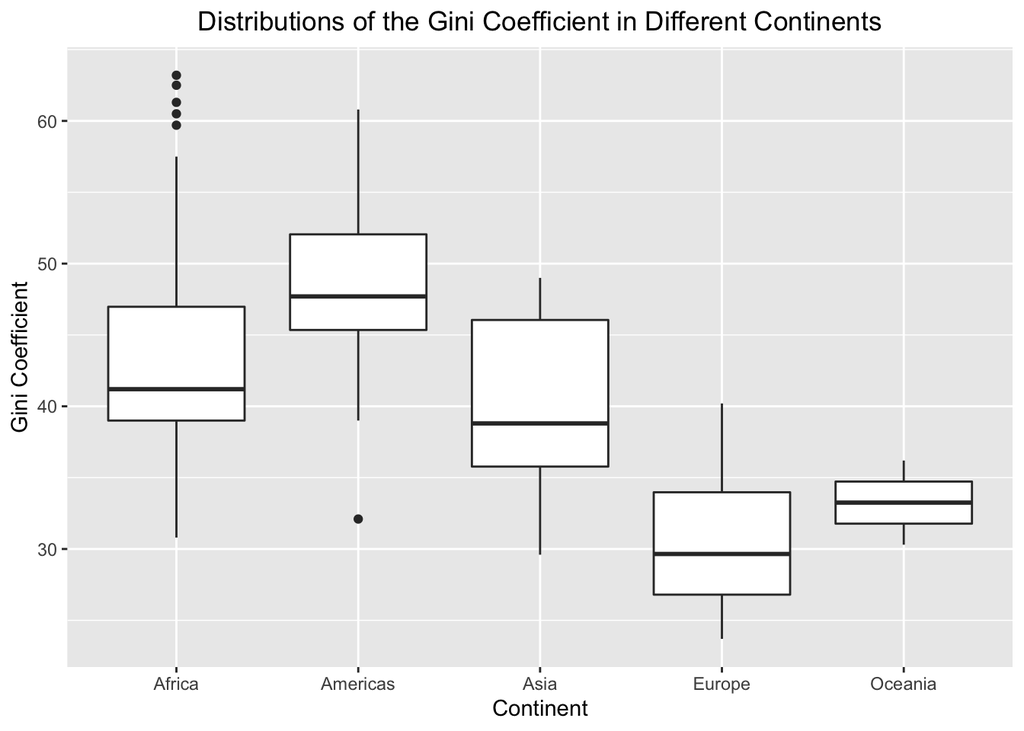

```r
gapminder2007 %>%
  ggplot(aes(x = continent, y = gini)) +
  geom_boxplot() + # box plot
  labs(
    x = "Continent",
    y = "Gini Coefficient",
    title = "Distributions of the Gini Coefficient in Different Continents"
  ) +
  theme(plot.title = element_text(hjust = 0.5))
```

### (2b) Does the Gini coefficient appear to have any impact on the life expectancy in 2007? Explain your answer using a plot, classified by continents.

We first draw the box plot of the life expectancy and then compare it with the above gini coefficient graph.

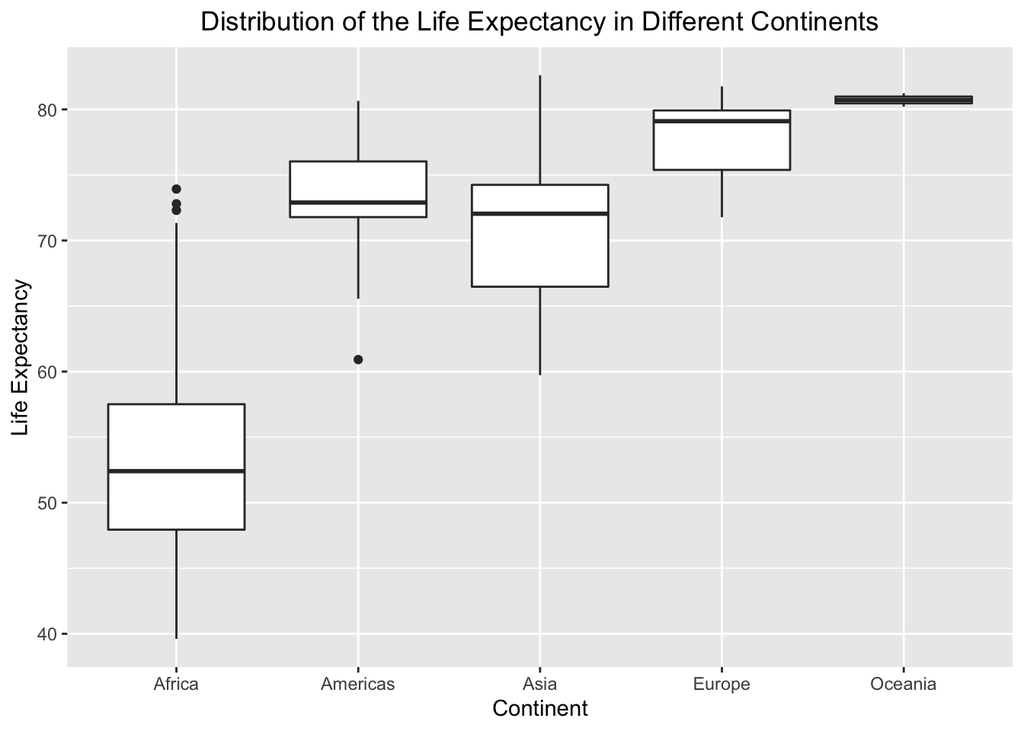

```r
gapminder2007 %>%
  ggplot(aes(x = continent, y = lifeExp)) +
  geom_boxplot() + # box plot
  labs(
    x = "Continent",
    y = "Life Expectancy",
    title = "Distribution of the Life Expectancy in Different Continents"
  ) +
  theme(plot.title = element_text(hjust = 0.5))
```

Based the above box plot about life expectancy and the box plot in 2a about the Gini coefficient, we can see that the Gini coefficient can reflect the life expectancy. A low Gini coefficient may indicate a relative high life expectancy and when people’s Gini coefficient tend to be equal, their life expectancy tend to be the same age as well.

## 3. Using the original gapminder data frame, please generate a data frame with a new variable called gdp by multiplying the population size by the gdp per capita. To make those large numbers more understandable, please form an additional new variable called gdp_ratio equal to the gdp divided by the gdp of the United States in 2007. Find the median gdp_ratio by continent and year, and then plot the median gdp_ratio over time, distinguishing the continents. Please use both points and lines for the plot.

### Install the original gapminder package and show the data.

```r
gapminder # the original gapminder
```

```
## # A tibble: 1,704 × 6
##    country     continent  year lifeExp      pop gdpPercap
##    <fct>       <fct>     <int>   <dbl>    <int>     <dbl>
##  1 Afghanistan Asia       1952    28.8  8425333      779.
##  2 Afghanistan Asia       1957    30.3  9240934      821.
##  3 Afghanistan Asia       1962    32.0 10267083      853.
##  4 Afghanistan Asia       1967    34.0 11537966      836.
##  5 Afghanistan Asia       1972    36.1 13079460      740.
##  6 Afghanistan Asia       1977    38.4 14880372      786.
##  7 Afghanistan Asia       1982    39.9 12881816      978.
##  8 Afghanistan Asia       1987    40.8 13867957      852.
##  9 Afghanistan Asia       1992    41.7 16317921      649.
## 10 Afghanistan Asia       1997    41.8 22227415      635.
## # … with 1,694 more rows
```

### Add two columns: gdp and gdp_ratio.

```r
# convert tibble to data frame
gapminderWithGDP <- as.data.frame(gapminder)
# generate a new column called gdp
gapminderWithGDP$gdp <- gapminderWithGDP$pop * gapminderWithGDP$gdpPercap
# compute and get the gdp of the United States in 2007
us2007GDP <- gapminderWithGDP %>%
  filter(year == 2007, country == "United States") %>%
  pull(gdp)

# generate a new column called gdp_ratio
gapminderWithGDP$gdp_ratio <- round(gapminderWithGDP$gdp / us2007GDP, 5)

# show the sorted data by continent, year and gdp_ratio
gapminderWithGDP %>%
  arrange(continent, year, gdp_ratio) %>%
  head(10)
```

```
##                  country continent year lifeExp     pop gdpPercap       gdp
## 1  Sao Tome and Principe    Africa 1952  46.471   60011  879.5836  52784691
## 2                Comoros    Africa 1952  40.715  153936 1102.9909 169790013
## 3               Djibouti    Africa 1952  34.812   63149 2669.5295 168578117
## 4      Equatorial Guinea    Africa 1952  34.482  216964  375.6431  81501035
## 5                 Gambia    Africa 1952  30.000  284320  485.2307 137960781
## 6          Guinea-Bissau    Africa 1952  32.500  580653  299.8503 174108987
## 7                Lesotho    Africa 1952  42.138  748747  298.8462 223760205
## 8               Botswana    Africa 1952  47.622  442308  851.2411 376510766
## 9              Swaziland    Africa 1952  41.407  290243 1148.3766 333308277
## 10               Eritrea    Africa 1952  35.928 1438760  328.9406 473266516
##    gdp_ratio
## 1      0e+00
## 2      1e-05
## 3      1e-05
## 4      1e-05
## 5      1e-05
## 6      1e-05
## 7      2e-05
## 8      3e-05
## 9      3e-05
## 10     4e-05
```

### Compute the median gdp_ratio by continent and year and plot the data via points and lines.

```r
# suppress the warning message of dplyr
options(dplyr.summarise.inform = F)

# compute the median gdp_ratio by continent and year
gapminderWithMedian <- gapminderWithGDP %>%
  group_by(year, continent) %>%
  summarize(median_gdp_ratio = median(gdp_ratio))

# show the sorted data by continent and year
gapminderWithMedian %>% arrange(continent, year)
```

```
## # A tibble: 60 × 3
## # Groups:   year [12]
##     year continent median_gdp_ratio
##    <int> <fct>                <dbl>
##  1  1952 Africa            0.000145
##  2  1957 Africa            0.000175
##  3  1962 Africa            0.00022
##  4  1967 Africa            0.000285
##  5  1972 Africa            0.000345
##  6  1977 Africa            0.000355
##  7  1982 Africa            0.00043
##  8  1987 Africa            0.00046
##  9  1992 Africa            0.00052
## 10  1997 Africa            0.000635
## # … with 50 more rows
```

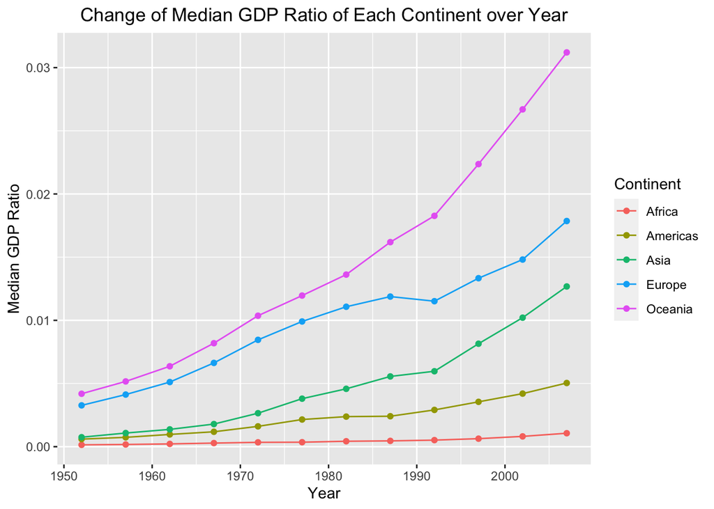

```r
# plot the median gdp_ration over time in different continents
gapminderWithMedian %>%
  ggplot(aes(x = year, y = median_gdp_ratio, color = continent)) +
  geom_line() + # line plot
  geom_point() + # point plot
  labs(
    x = "Year",
    y = "Median GDP Ratio",
    color = "Continent",
    title = "Change of Median GDP Ratio of Each Continent over Year"
  ) +
  theme(plot.title = element_text(hjust = 0.5))
```